# Dats6103-Individual Project2-Tejaswini Vuppu

Global Terrorism(1970-2017) - Project 2 - DATS 6103

Data Science, Columbian College of Arts & Sciences, George Washington University

Individual Project 2  
Author: Tejaswini Vuppu

</b>

# Overview

#### file name : globalterrorismdb_0718dist.csv

```python
# skipping warnings.
import warnings
warnings.filterwarnings('ignore')
```

```python
import pandas as pd
import seaborn as sns # seaborn to visualize plots
import numpy as np

# dataset  website link :- "https://www.kaggle.com/START-UMD/gtd"

dfRaw = pd.read_csv("globalterrorismdb_0718dist.csv",encoding="ISO-8859-1")
```

```python
display(dfRaw.head())
```

|  | eventid | iyear | imonth | iday | approxdate | extended | resolution | country | country_txt | region | ... | addnotes | scite1 | scite2 | scite3 | dbsource | INT_LOG | INT_IDEO | INT_MISC | INT_ANY | related |
| --- | --- | --- | --- | --- | --- | --- | --- | --- | --- | --- | --- | --- | --- | --- | --- | --- | --- | --- | --- | --- | --- |
| 0 | 197000000001 | 1970 | 7 | 2 | NaN | 0 | NaN | 58 | Dominican Republic | 2 | ... | NaN | NaN | NaN | NaN | PGIS | 0 | 0 | 0 | 0 | NaN |
| 1 | 197000000002 | 1970 | 0 | 0 | NaN | 0 | NaN | 130 | Mexico | 1 | ... | NaN | NaN | NaN | NaN | PGIS | 0 | 1 | 1 | 1 | NaN |
| 2 | 197001000001 | 1970 | 1 | 0 | NaN | 0 | NaN | 160 | Philippines | 5 | ... | NaN | NaN | NaN | NaN | PGIS | -9 | -9 | 1 | 1 | NaN |
| 3 | 197001000002 | 1970 | 1 | 0 | NaN | 0 | NaN | 78 | Greece | 8 | ... | NaN | NaN | NaN | NaN | PGIS | -9 | -9 | 1 | 1 | NaN |
| 4 | 197001000003 | 1970 | 1 | 0 | NaN | 0 | NaN | 101 | Japan | 4 | ... | NaN | NaN | NaN | NaN | PGIS | -9 | -9 | 1 | 1 | NaN |

5 rows × 135 columns

```python
# Lets rename the columns
dfRaw.rename(columns={'iyear':'Year','imonth':'Month','iday':'Day','country_txt':'Country','region_txt':'Region','attacktype1_txt':'AttackType','target1':'Target','nkill':'Killed','nwound':'Wounded','summary':'Summary','gname':'Group','targtype1_txt':'Target_type','weaptype1_txt':'Weapon_type','motive':'Motive','natlty1_txt':'Nationality'},inplace=True)
```

```python
display(dfRaw)
```

[output not shown]

181691 rows × 135 columns

```python
#Displays the data frame summary info
dfRaw.info()
```

```
<class 'pandas.core.frame.DataFrame'>
RangeIndex: 181691 entries, 0 to 181690
Columns: 135 entries, eventid to related
dtypes: float64(55), int64(22), object(58)
memory usage: 187.1+ MB
```

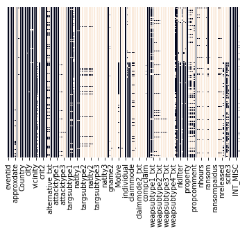

```python
sns.heatmap(dfRaw.isnull(), cbar=False,yticklabels=False)
```

By looking at the graph we see there are lot of columns that are empty, Let's keep a threshold of 65% and will remove the columns which doesn't have more than 65% values as empty.

```python
THRESHOLD = .65
list_columns_drop = []
for col in dfRaw.columns.tolist():
    null_per = dfRaw[col].isnull().sum() / len(dfRaw[col])
    if null_per > THRESHOLD:
        list_columns_drop.append(col)
        print (col, "will be dropped because of null percentage: ", null_per)
dfRaw.drop(list_columns_drop, inplace=True,axis=1)
```

```
approxdate will be dropped because of null percentage:  0.9491499303762982
resolution will be dropped because of null percentage:  0.9877814531264619
location will be dropped because of null percentage:  0.6945638474112642
alternative will be dropped because of null percentage:  0.8403278093026072
alternative_txt will be dropped because of null percentage:  0.8403278093026072
attacktype2 will be dropped because of null percentage:  0.9652486914596761
attacktype2_txt will be dropped because of null percentage:  0.9652486914596761
attacktype3 will be dropped because of null percentage:  0.997644352224381
attacktype3_txt will be dropped because of null percentage:  0.997644352224381
targtype2 will be dropped because of null percentage:  0.9386650962348162
targtype2_txt will be dropped because of null percentage:  0.9386650962348162
targsubtype2 will be dropped because of null percentage:  0.9411913633586694
targsubtype2_txt will be dropped because of null percentage:  0.9411913633586694
corp2 will be dropped because of null percentage:  0.9443175501263134
target2 will be dropped because of null percentage:  0.9393475736277526
natlty2 will be dropped because of null percentage:  0.9404043128168154
natlty2_txt will be dropped because of null percentage:  0.9404043128168154
targtype3 will be dropped because of null percentage:  0.9935274724669907
targtype3_txt will be dropped because of null percentage:  0.9935274724669907
targsubtype3 will be dropped because of null percentage:  0.9939622766124905
targsubtype3_txt will be dropped because of null percentage:  0.9939622766124905
corp3 will be dropped because of null percentage:  0.994353049958446
target3 will be dropped because of null percentage:  0.9935329763169337
natlty3 will be dropped because of null percentage:  0.9936870841153387
natlty3_txt will be dropped because of null percentage:  0.9936870841153387
gsubname will be dropped because of null percentage:  0.9675823238355229
gname2 will be dropped because of null percentage:  0.9889207500646703
gsubname2 will be dropped because of null percentage:  0.9991193840091144
gname3 will be dropped because of null percentage:  0.9982167526184567
gsubname3 will be dropped because of null percentage:  0.9998899230011393
Motive will be dropped because of null percentage:  0.7217198430301996
guncertain2 will be dropped because of null percentage:  0.9892399733613663
guncertain3 will be dropped because of null percentage:  0.9982387680182288
claimmode will be dropped because of null percentage:  0.8949700315370602
claimmode_txt will be dropped because of null percentage:  0.8949700315370602
claim2 will be dropped because of null percentage:  0.9895977236076635
claimmode2 will be dropped because of null percentage:  0.9966096284350904
claimmode2_txt will be dropped because of null percentage:  0.9966096284350904
claim3 will be dropped because of null percentage:  0.9982497757181148
claimmode3 will be dropped because of null percentage:  0.9992679879575763
```

[output cut: 18 more lines]

```
nhours will be dropped because of null percentage:  0.9776378576814482
ndays will be dropped because of null percentage:  0.9552867230627824
divert will be dropped because of null percentage:  0.9982167526184567
kidhijcountry will be dropped because of null percentage:  0.9818097759382688
ransomamt will be dropped because of null percentage:  0.9925698025769025
ransomamtus will be dropped because of null percentage:  0.9969013324820712
ransompaid will be dropped because of null percentage:  0.9957400201440908
ransompaidus will be dropped because of null percentage:  0.9969618748314446
ransomnote will be dropped because of null percentage:  0.9971710211292799
hostkidoutcome will be dropped because of null percentage:  0.9395071852761007
hostkidoutcome_txt will be dropped because of null percentage:  0.9395071852761007
nreleased will be dropped because of null percentage:  0.9427599605924344
addnotes will be dropped because of null percentage:  0.8443015889614786
scite3 will be dropped because of null percentage:  0.7604944658788823
related will be dropped because of null percentage:  0.8621946051262859
```

Now make sure the data looks good ?

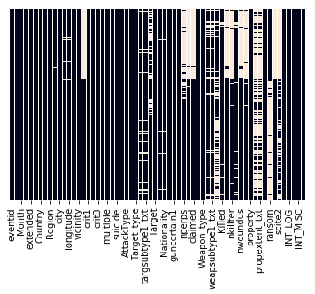

```python
sns.heatmap(dfRaw.isnull(), cbar=False,yticklabels=False)
```

Now the data looks good, let's make sure are there any duplicates in the dataset

```python
# There are no duplicate values in the dataset, which is good.!
# Let's move on..!!
dfRaw[dfRaw.duplicated(keep=False)]
```

|  | eventid | Year | Month | Day | extended | country | Country | region | Region | provstate | ... | propextent_txt | ishostkid | ransom | scite1 | scite2 | dbsource | INT_LOG | INT_IDEO | INT_MISC | INT_ANY |
| --- | --- | --- | --- | --- | --- | --- | --- | --- | --- | --- | --- | --- | --- | --- | --- | --- | --- | --- | --- | --- | --- |

0 rows × 62 columns

Now lets see how many null values are there and will remove them

```python
dfRaw.columns
```

```
Index(['eventid', 'Year', 'Month', 'Day', 'extended', 'country', 'Country',
       'region', 'Region', 'provstate', 'city', 'latitude', 'longitude',
       'specificity', 'vicinity', 'Summary', 'crit1', 'crit2', 'crit3',
       'doubtterr', 'multiple', 'success', 'suicide', 'attacktype1',
       'AttackType', 'targtype1', 'Target_type', 'targsubtype1',
       'targsubtype1_txt', 'corp1', 'Target', 'natlty1', 'Nationality',
       'Group', 'guncertain1', 'individual', 'nperps', 'nperpcap', 'claimed',
       'weaptype1', 'Weapon_type', 'weapsubtype1', 'weapsubtype1_txt',
       'weapdetail', 'Killed', 'nkillus', 'nkillter', 'Wounded', 'nwoundus',
       'nwoundte', 'property', 'propextent', 'propextent_txt', 'ishostkid',
       'ransom', 'scite1', 'scite2', 'dbsource', 'INT_LOG', 'INT_IDEO',
       'INT_MISC', 'INT_ANY'],
      dtype='object')
```

The metadata explains that the gname is the name of the group that carried out the attack, lets see how many groups we still don't know about who attacked ?

```python
print("The total number of attacks heppend are : ",len(dfRaw))
print("Among them the number of attacks that we still not known are : ",len(dfRaw[dfRaw["Group"] == "Unknown"]))
print("The known attacks are : ",len(dfRaw[dfRaw["Group"] != "Unknown"]))
```

```
The total number of attacks heppend are :  181691
Among them the number of attacks that we still not known are :  82782
The known attacks are :  98909
```

#### Lets see some values by the natioality/group/attacks and then will decide on what makes us interesting to find from this dataset ?

```python
#Number of attacks with the groupname
dfRaw.groupby("Group").size().head()
```

```
Group
1 May                                  10
14 K Triad                              4
14 March Coalition                      1
14th of December Command                3
15th of September Liberation Legion     1
dtype: int64
```

#### Number of kills by each group

```python
kills_by_group = dfRaw.groupby("Group")["Killed"].sum().sort_values(ascending=False)
kills_by_group.head()
```

```
Group
Unknown                                        112367.0
Islamic State of Iraq and the Levant (ISIL)     38923.0
Taliban                                         29410.0
Boko Haram                                      20328.0
Shining Path (SL)                               11601.0
Name: Killed, dtype: float64
```

#### Number of terrorist activities by year

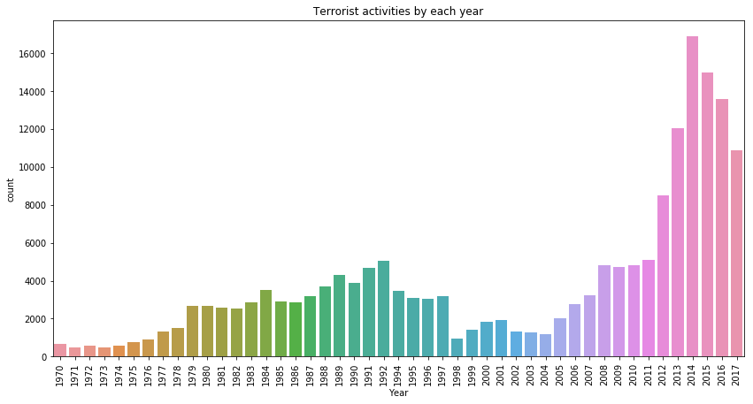

```python
import matplotlib.pyplot as plt

plt.subplots(figsize=(14,7))
sns.countplot('Year',data=dfRaw)
plt.xticks(rotation=90)
plt.title('Terrorist activities by each year')
plt.show()
```

#### Activities by Region across the years

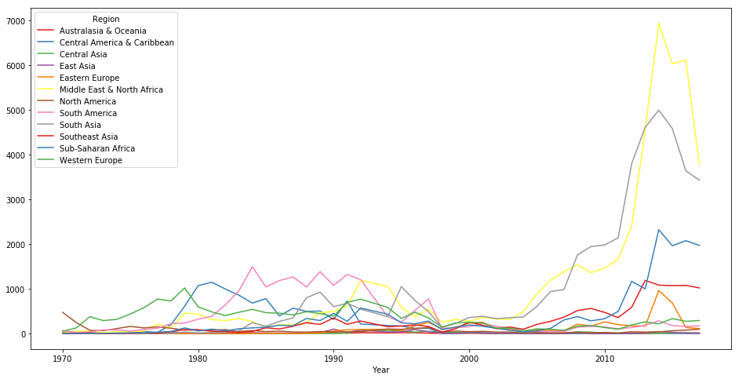

```python
dfRaw_region=pd.crosstab(dfRaw.Year,dfRaw.Region)
dfRaw_region.plot(color=sns.color_palette('Set1',18))
fig=plt.gcf()
fig.set_size_inches(16,8)
plt.show()
```

#### Attacking Method by terrorists

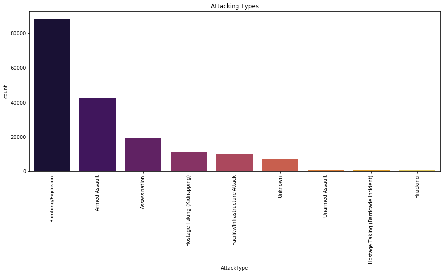

```python
plt.subplots(figsize=(15,6))
sns.countplot('AttackType',data=dfRaw,palette='inferno',order=dfRaw['AttackType'].value_counts().index)
plt.title('Attacking Types')
plt.xticks(rotation=90)
plt.show()
```

#### Most effective terrorist group

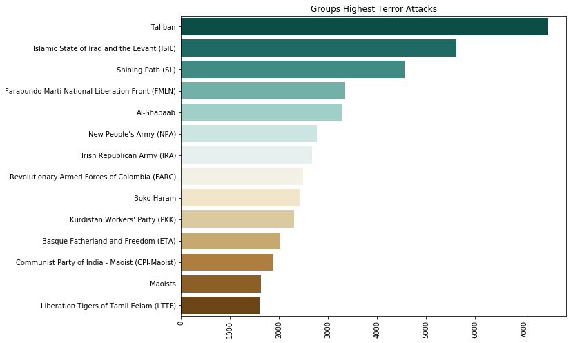

```python
sns.barplot(dfRaw['Group'].value_counts()[1:15].values,dfRaw['Group'].value_counts()[1:15].index,palette=('BrBG_r'))
plt.xticks(rotation=90)
plt.title('Groups Highest Terror Attacks')
fig=plt.gcf()
fig.set_size_inches(10,8)
plt.show()
```

### Question : Let's find out if a person belongs to a place, How likely he could be a terrorist ?

```python
# It looks like countrys are some country codes, It's not much useful for geopandas
dfRaw["Country"].head()
```

```
0    Dominican Republic
1                Mexico
2           Philippines
3                Greece
4                 Japan
Name: Country, dtype: object
```

```python
attacks_by_nationality = dfRaw.groupby(["Nationality"]).size().reset_index(name='count')
```

```python
import plotly as py
import plotly.graph_objs as go
import pandas as pd

from plotly.offline import download_plotlyjs, init_notebook_mode, plot, iplot
init_notebook_mode()


data = dict (
    type = 'choropleth',
    locations = attacks_by_nationality["Nationality"],
    locationmode='country names',
    autocolorscale = False,
    z=attacks_by_nationality["count"])

map = go.Figure(data=[data])
py.offline.iplot(map)
```

[interactive chart not shown]

With this information we can see the list of countrys where attacks are really high, but we are not considering the population and other factors into this. Let's understand more to see that our assumption is correct ?

```python
# Lets find the top countries list where the number of attacks are happening, and will see how many other country attacks are there ?
attacks_by_nationality.sort_values(by=['count'],ascending=False).head()
```

|  | Nationality | count |
| --- | --- | --- |
| 86 | Iraq | 24113 |
| 141 | Pakistan | 13900 |
| 82 | India | 12098 |
| 0 | Afghanistan | 10931 |
| 36 | Colombia | 7922 |

```python
# Lets create a function to print all the map data for better visualization

def print_map_data(df_map_data):
    data = dict (
    type = 'choropleth',
    locations = df_map_data["Nationality"],
    locationmode='country names',
    autocolorscale = False,
    z=df_map_data["count"])
    map = go.Figure(data=[data])
    py.offline.iplot(map)
```

#### Iraq

```python
iraq_attacks = dfRaw.loc[dfRaw['Country'] == 'Iraq', ['Country', 'Nationality']].groupby(['Country', 'Nationality']).size().reset_index(name='count')
print_map_data(iraq_attacks)
```

[interactive chart not shown]

#### When you look at the above data most number of attacks are done by their country people, Let's make sure with some other countries

#### Pakistan

```python
pakistan_attacks = dfRaw.loc[dfRaw['Country'] == 'Pakistan', ['Country', 'Nationality']].groupby(['Country', 'Nationality']).size().reset_index(name='count')
print_map_data(pakistan_attacks)
```

[interactive chart not shown]

#### India

```python
india_attacks = dfRaw.loc[dfRaw['Country'] == 'India', ['Country', 'Nationality']].groupby(['Country', 'Nationality']).size().reset_index(name='count')
print_map_data(india_attacks)
```

[interactive chart not shown]

#### United States

```python
# As we are in US, Lets see ours?
us_attacks = dfRaw.loc[dfRaw['Country'] == 'United States', ['Country', 'Nationality']].groupby(['Country', 'Nationality']).size().reset_index(name='count')
print_map_data(us_attacks)
```

[interactive chart not shown]

#### With the above data observation we can conclude that most of the terror activities are done by their country people, With that we can conclude this by saying it could be different facts of their countrys culture or people who are ruling them

## RandomForest Model

```python
# Cleaning data for model

df=dfRaw[['Year','Month','Day','Country','Region','city','latitude','longitude','AttackType','Killed','Wounded','Target','Summary','Group','Target_type','Weapon_type']]
df['KillAndWound']=df['Killed']+df['Wounded']
df.head()
```

|  | Year | Month | Day | Country | Region | city | latitude | longitude | AttackType | Killed | Wounded | Target | Summary | Group | Target_type | Weapon_type | KillAndWound |
| --- | --- | --- | --- | --- | --- | --- | --- | --- | --- | --- | --- | --- | --- | --- | --- | --- | --- |
| 0 | 1970 | 7 | 2 | Dominican Republic | Central America & Caribbean | Santo Domingo | 18.456792 | -69.951164 | Assassination | 1.0 | 0.0 | Julio Guzman | NaN | MANO-D | Private Citizens & Property | Unknown | 1.0 |
| 1 | 1970 | 0 | 0 | Mexico | North America | Mexico city | 19.371887 | -99.086624 | Hostage Taking (Kidnapping) | 0.0 | 0.0 | Nadine Chaval, daughter | NaN | 23rd of September Communist League | Government (Diplomatic) | Unknown | 0.0 |
| 2 | 1970 | 1 | 0 | Philippines | Southeast Asia | Unknown | 15.478598 | 120.599741 | Assassination | 1.0 | 0.0 | Employee | NaN | Unknown | Journalists & Media | Unknown | 1.0 |
| 3 | 1970 | 1 | 0 | Greece | Western Europe | Athens | 37.997490 | 23.762728 | Bombing/Explosion | NaN | NaN | U.S. Embassy | NaN | Unknown | Government (Diplomatic) | Explosives | NaN |
| 4 | 1970 | 1 | 0 | Japan | East Asia | Fukouka | 33.580412 | 130.396361 | Facility/Infrastructure Attack | NaN | NaN | U.S. Consulate | NaN | Unknown | Government (Diplomatic) | Incendiary | NaN |

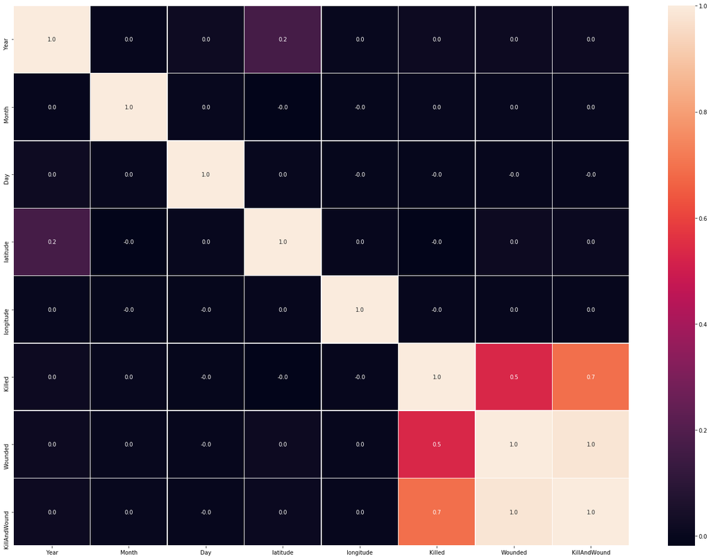

```python
#correlation map

f,ax = plt.subplots(figsize=(25, 18))
sns.heatmap(df.corr(), annot=True, linewidths=.5, fmt= '.1f',ax=ax)
plt.show()
```

```python
df = df.drop(columns = ['Target','Summary','city'])
df = df.dropna()
```

Lets convert the string type columns into numbers using LabelEncoder which will help us encode and then decode when needed.

```python
from sklearn.preprocessing import LabelEncoder
from sklearn.preprocessing import label_binarize

labelEncoding = LabelEncoder()
df['Country'] = labelEncoding.fit_transform(df['Country'])
df['Target_type'] = labelEncoding.fit_transform(df['Target_type'])
df['AttackType'] = labelEncoding.fit_transform(df['AttackType'])
df['Weapon_type'] = labelEncoding.fit_transform(df['Weapon_type'])
df['Region'] = labelEncoding.fit_transform(df['Region'])
df['Group'] = labelEncoding.fit_transform(df['Group'])

df['KillAndWound'] = df['KillAndWound'].apply(lambda x: 0 if x == 0 else 1)


df
```

|  | Year | Month | Day | Country | Region | latitude | longitude | AttackType | Killed | Wounded | Group | Target_type | Weapon_type | KillAndWound |
| --- | --- | --- | --- | --- | --- | --- | --- | --- | --- | --- | --- | --- | --- | --- |
| 0 | 1970 | 7 | 2 | 45 | 1 | 18.456792 | -69.951164 | 1 | 1.0 | 0.0 | 1789 | 13 | 10 | 1 |
| 1 | 1970 | 0 | 0 | 113 | 6 | 19.371887 | -99.086624 | 6 | 0.0 | 0.0 | 12 | 5 | 10 | 0 |
| 2 | 1970 | 1 | 0 | 137 | 9 | 15.478598 | 120.599741 | 1 | 1.0 | 0.0 | 3185 | 7 | 10 | 1 |
| 5 | 1970 | 1 | 1 | 186 | 6 | 37.005105 | -89.176269 | 0 | 0.0 | 0.0 | 647 | 12 | 4 | 0 |
| 6 | 1970 | 1 | 2 | 187 | 7 | -34.891151 | -56.187214 | 1 | 0.0 | 0.0 | 3070 | 12 | 4 | 0 |
| 7 | 1970 | 1 | 2 | 186 | 6 | 37.791927 | -122.225906 | 2 | 0.0 | 0.0 | 3185 | 20 | 2 | 0 |
| 8 | 1970 | 1 | 2 | 186 | 6 | 43.076592 | -89.412488 | 3 | 0.0 | 0.0 | 2134 | 9 | 5 | 0 |
| 9 | 1970 | 1 | 3 | 186 | 6 | 43.072950 | -89.386694 | 3 | 0.0 | 0.0 | 2134 | 6 | 5 | 0 |
| 10 | 1970 | 1 | 1 | 186 | 6 | 43.468500 | -89.744299 | 2 | 0.0 | 0.0 | 3220 | 9 | 2 | 0 |
| 11 | 1970 | 1 | 6 | 186 | 6 | 39.758968 | -104.876305 | 3 | 0.0 | 0.0 | 1733 | 9 | 5 | 0 |
| 12 | 1970 | 1 | 8 | 84 | 11 | 41.890961 | 12.490069 | 4 | 0.0 | 0.0 | 3185 | 1 | 4 | 0 |
| 13 | 1970 | 1 | 9 | 186 | 6 | 42.331685 | -83.047924 | 3 | 0.0 | 0.0 | 1733 | 6 | 5 | 0 |
| 14 | 1970 | 1 | 9 | 186 | 6 | 18.386932 | -66.061127 | 3 | 0.0 | 0.0 | 420 | 2 | 5 | 0 |
| 17 | 1970 | 1 | 12 | 186 | 6 | 40.697132 | -73.931351 | 2 | 0.0 | 0.0 | 647 | 3 | 2 | 0 |
| 18 | 1970 | 1 | 12 | 186 | 6 | 18.379998 | -65.830948 | 2 | 0.0 | 0.0 | 2847 | 2 | 2 | 0 |
| 19 | 1970 | 1 | 13 | 186 | 6 | 47.610786 | -122.331306 | 3 | 0.0 | 0.0 | 647 | 2 | 5 | 0 |
| 20 | 1970 | 1 | 14 | 186 | 6 | 40.116748 | -88.239270 | 3 | 0.0 | 1.0 | 647 | 12 | 5 | 1 |
| 21 | 1970 | 1 | 15 | 187 | 7 | -34.891151 | -56.187214 | 0 | 0.0 | 0.0 | 3070 | 3 | 4 | 0 |
| 22 | 1970 | 1 | 19 | 186 | 6 | 47.610786 | -122.331306 | 2 | 0.0 | 0.0 | 647 | 3 | 2 | 0 |
| 23 | 1970 | 1 | 19 | 186 | 6 | 47.610786 | -122.331306 | 2 | 0.0 | 0.0 | 2854 | 9 | 2 | 0 |
| 24 | 1970 | 1 | 19 | 186 | 6 | 40.717892 | -74.067467 | 3 | 0.0 | 0.0 | 3236 | 21 | 5 | 0 |
| 25 | 1970 | 1 | 20 | 68 | 1 | 14.622869 | -90.529068 | 1 | 1.0 | 0.0 | 3185 | 5 | 10 | 1 |
| 26 | 1970 | 1 | 21 | 137 | 9 | 14.674280 | 121.057495 | 2 | 0.0 | 0.0 | 3185 | 5 | 2 | 0 |
| 27 | 1970 | 1 | 22 | 191 | 7 | 10.482834 | -66.962128 | 6 | 0.0 | 0.0 | 434 | 2 | 10 | 0 |
| 28 | 1970 | 1 | 22 | 186 | 6 | 42.470310 | -96.413949 | 2 | 0.0 | 0.0 | 2847 | 13 | 2 | 0 |
| 29 | 1970 | 1 | 25 | 186 | 6 | 33.606510 | -88.650419 | 3 | 0.0 | 0.0 | 3236 | 13 | 5 | 0 |
| 30 | 1970 | 1 | 25 | 186 | 6 | 40.697132 | -73.931351 | 0 | 0.0 | 2.0 | 647 | 12 | 4 | 1 |
| 31 | 1970 | 1 | 26 | 186 | 6 | 33.606510 | -88.650419 | 2 | 0.0 | 0.0 | 647 | 6 | 2 | 0 |
| 32 | 1970 | 1 | 26 | 186 | 6 | 40.697132 | -73.931351 | 0 | 0.0 | 0.0 | 647 | 12 | 4 | 0 |
| 33 | 1970 | 1 | 27 | 186 | 6 | 41.241996 | -82.615241 | 3 | 0.0 | 0.0 | 1733 | 6 | 5 | 0 |
| ... | ... | ... | ... | ... | ... | ... | ... | ... | ... | ... | ... | ... | ... | ... |
| 181658 | 2017 | 12 | 30 | 90 | 10 | -1.595245 | 40.514259 | 2 | 0.0 | 0.0 | 169 | 15 | 2 | 0 |
| 181659 | 2017 | 12 | 30 | 90 | 10 | -1.595245 | 40.514259 | 3 | 0.0 | 0.0 | 169 | 2 | 4 | 0 |
| 181660 | 2017 | 12 | 30 | 183 | 4 | 49.993500 | 36.230383 | 5 | 0.0 | 1.0 | 3185 | 6 | 2 | 1 |
| 181661 | 2017 | 12 | 28 | 77 | 8 | 17.001086 | 81.807490 | 3 | 1.0 | 0.0 | 3185 | 14 | 5 | 1 |
| 181663 | 2017 | 12 | 30 | 77 | 8 | 11.831902 | 75.565432 | 2 | 0.0 | 0.0 | 3185 | 12 | 2 | 0 |
| 181664 | 2017 | 12 | 30 | 185 | 11 | 54.607712 | -5.956210 | 0 | 0.0 | 2.0 | 3185 | 13 | 4 | 1 |
| 181665 | 2017 | 12 | 30 | 77 | 8 | 18.802725 | 81.497666 | 3 | 0.0 | 0.0 | 835 | 2 | 4 | 0 |
| 181668 | 2017 | 12 | 31 | 81 | 5 | 35.560376 | 44.524705 | 2 | 0.0 | 0.0 | 3185 | 9 | 2 | 0 |
| 181669 | 2017 | 12 | 30 | 81 | 5 | 35.452110 | 44.375465 | 2 | 0.0 | 5.0 | 3185 | 2 | 2 | 1 |
| 181670 | 2017 | 12 | 31 | 81 | 5 | 33.816111 | 44.783524 | 8 | 1.0 | 0.0 | 1437 | 12 | 10 | 1 |
| 181671 | 2017 | 12 | 31 | 81 | 5 | 34.031331 | 44.070106 | 2 | 4.0 | 9.0 | 1437 | 13 | 2 | 1 |
| 181672 | 2017 | 12 | 31 | 77 | 8 | 33.966527 | 74.964225 | 0 | 8.0 | 3.0 | 1479 | 12 | 2 | 1 |
| 181673 | 2017 | 12 | 31 | 0 | 8 | 34.417122 | 70.449593 | 2 | 18.0 | 14.0 | 1636 | 13 | 2 | 1 |
| 181674 | 2017 | 12 | 31 | 81 | 5 | 36.045059 | 41.716717 | 8 | 5.0 | 0.0 | 1437 | 9 | 10 | 1 |
| 181675 | 2017 | 12 | 31 | 156 | 10 | 2.059819 | 45.326115 | 2 | 2.0 | 3.0 | 169 | 9 | 2 | 1 |
| 181676 | 2017 | 12 | 31 | 0 | 8 | 34.217806 | 69.109316 | 2 | 5.0 | 0.0 | 2935 | 12 | 2 | 1 |
| 181677 | 2017 | 12 | 31 | 137 | 9 | 6.983953 | 124.420664 | 3 | 0.0 | 0.0 | 573 | 13 | 4 | 0 |
| 181678 | 2017 | 12 | 30 | 137 | 9 | 7.053143 | 124.619270 | 2 | 1.0 | 1.0 | 3185 | 2 | 2 | 1 |
| 181679 | 2017 | 12 | 31 | 81 | 5 | 33.953167 | 44.921906 | 0 | 13.0 | 0.0 | 1437 | 9 | 4 | 1 |
| 181680 | 2017 | 12 | 31 | 156 | 10 | 3.810951 | 43.246506 | 2 | 0.0 | 0.0 | 169 | 9 | 2 | 0 |
| 181681 | 2017 | 12 | 31 | 137 | 9 | 6.862806 | 124.443649 | 2 | 1.0 | 5.0 | 573 | 12 | 2 | 1 |
| 181682 | 2017 | 12 | 31 | 84 | 11 | 42.888982 | 13.772795 | 3 | 0.0 | 0.0 | 3185 | 13 | 5 | 0 |
| 181683 | 2017 | 12 | 31 | 0 | 8 | 35.315467 | 64.815508 | 0 | 6.0 | 0.0 | 2935 | 16 | 4 | 1 |
| 181684 | 2017 | 12 | 31 | 77 | 8 | 25.180162 | 93.015788 | 6 | 0.0 | 0.0 | 3290 | 6 | 4 | 0 |
| 181685 | 2017 | 12 | 31 | 0 | 8 | 35.921051 | 64.774544 | 2 | 0.0 | 4.0 | 3185 | 2 | 2 | 1 |
| 181686 | 2017 | 12 | 31 | 156 | 10 | 2.359673 | 45.385034 | 0 | 1.0 | 2.0 | 169 | 9 | 4 | 1 |
| 181687 | 2017 | 12 | 31 | 172 | 5 | 35.407278 | 35.942679 | 2 | 2.0 | 7.0 | 2006 | 9 | 2 | 1 |
| 181688 | 2017 | 12 | 31 | 137 | 9 | 6.900742 | 124.437908 | 3 | 0.0 | 0.0 | 573 | 13 | 5 | 0 |
| 181689 | 2017 | 12 | 31 | 77 | 8 | 24.798346 | 93.940430 | 2 | 0.0 | 0.0 | 3185 | 6 | 2 | 0 |
| 181690 | 2017 | 12 | 31 | 137 | 9 | 7.209594 | 124.241966 | 2 | 0.0 | 0.0 | 3185 | 19 | 2 | 0 |

160916 rows × 14 columns

```python
# devide the data into train and test

from sklearn.model_selection import train_test_split
from sklearn.model_selection import cross_val_score


# Split data for training data and validation data
X = df[['Year','Country','Region','latitude','longitude','AttackType','Group','Target_type','Weapon_type']]
valid = df['KillAndWound']


X_train, X_test, valid_train, valid_test = train_test_split(X, valid, test_size=0.3)
```

```python
from sklearn.ensemble import RandomForestClassifier
model = RandomForestClassifier(n_estimators=10)
model.fit(X_train, valid_train)
pred = model.predict(X_test)
np.mean(pred == valid_test)
```

```
0.8221853961677887
```

The accuracy of the model looks like its 82% percent.